Basic Goal: Is recall systematically distorted based on statistical regularities? How are these distortions characterized in terms of unbiased, biased, and guess distributions?

Below is a summary of the behavioral experiment that was run (Exp 1), followed by current modeling approaches. Then I present a replication of the experiment (with small tweak) that I ran the first few weeks of the semester (Exp 2). There are some comments throughout and potential next steps at the end.

# Exp 1

## Design

20 participants were collected (4 excluded due to <80% performance at repeat detection task)

### Study Phase

- 336 objects presented sequentially, with color sampling from a biased color wheel partitioned into 4 quadrants. One quadrant ("rich quadrant") is preferentially sampled so that 50% of objects are in this color region. Quadrants are randomly selected for every subject, and sampling follows a uniform distribution for each quadrant.
- An additional 30 objects are presented at random times throughout study phase, in which these objects are presented twice in a row. The task is to press the spacebar whenever an object immediately repeats. These repeated objects are not presented in the test phase. Therefore the total trial count for the study phase was 336 + (30*2) = 396.

### Test Phase

- Continuous color report

## Non-modelling Behavioral Results

Here I have characterized the color responses for each subject according to whether their response was closer/towards to the rich quadrant or farther/away from the rich quadrant, compared to the original color. (Note that some trials are discarded because they either answered the color exactly correct, exactly 180 degrees away from the correct color, or they clicked without moving the mouse which invalidated the trial.)

| all quads (each column is one subject) |  |  |  |  |  |  |  |  |  |  |  |  |  |  |  |  |  |
| --- | --- | --- | --- | --- | --- | --- | --- | --- | --- | --- | --- | --- | --- | --- | --- | --- | --- |
| closer |  |  |  |  |  |  |  |  |  |  |  |  |  |  |  | Means | P-value |
| 228 | 163 | 175 | 230 | 204 | 170 | 177 | 168 | 211 | 157 | 104 | 129 | 169 | 136 | 173 | 161 | 172.1875 |  |
| farther |  |  |  |  |  |  |  |  |  |  |  |  |  |  |  |  | 0.013864233 |
| 97 | 165 | 157 | 103 | 127 | 161 | 153 | 162 | 68 | 122 | 172 | 146 | 112 | 142 | 109 | 113 | 131.8125 |  |

| neigh quads |  |  |  |  |  |  |  |  |  |  |  |  |  |  |  |  |  |
| --- | --- | --- | --- | --- | --- | --- | --- | --- | --- | --- | --- | --- | --- | --- | --- | --- | --- |
| closer |  |  |  |  |  |  |  |  |  |  |  |  |  |  |  | Means | P-value |
| 70 | 47 | 58 | 71 | 71 | 55 | 57 | 53 | 65 | 42 | 29 | 35 | 53 | 35 | 61 | 49 | 53.1875 |  |
| farther |  |  |  |  |  |  |  |  |  |  |  |  |  |  |  |  | 0.3106125 |
| 39 | 61 | 54 | 41 | 40 | 55 | 52 | 58 | 26 | 49 | 58 | 56 | 38 | 56 | 33 | 45 | 47.5625 |  |

| rich quad |  |  |  |  |  |  |  |  |  |  |  |  |  |  |  |  |  |
| --- | --- | --- | --- | --- | --- | --- | --- | --- | --- | --- | --- | --- | --- | --- | --- | --- | --- |
| closer |  |  |  |  |  |  |  |  |  |  |  |  |  |  |  | Means | P-value |
| 126 | 77 | 77 | 119 | 95 | 82 | 83 | 78 | 116 | 85 | 49 | 65 | 85 | 75 | 80 | 80 | 85.75 |  |
| farther |  |  |  |  |  |  |  |  |  |  |  |  |  |  |  |  | 0.059129613 |
| 36 | 88 | 87 | 46 | 69 | 84 | 83 | 85 | 27 | 57 | 93 | 72 | 59 | 66 | 60 | 54 | 66.625 |  |

**Some problems** with Exp 1:

- Colors were not isoluminant across objects, due to objects having different shading.
- Did not record the original trial that each tested object was originally displayed at, which could have been useful for follow-up analyses.
- Did not do explicit continuous color response judgment at the end to gauge whether they realized the preferential color sampling. Instead did a 2AFC between 24 pairs of colors equidistant around the color wheel and a post-survey in which they were asked if they noticed colors were more likely to be of a certain color.

Post-survey: Do you think you selected certain colors more often than others, and if so what color?

Everyone said that they did think so, and approximately 1/3 of them correctly stated the color? Although this question I think could have been phrased much better, and some people didn't even state a color other than typing "yes".

Implicit memory test: 24 trials 15 degree mirrored color patch comparisons, asked which color appeared more frequently across objects

Only 2 people chose the color closer to the rich quadrant on over 60% of trials.

## Exp 1 Modelling

### Neighboring Quadrants (collapsed), Standard Mixture Model (with bias)

```
subjects collapsed; individually all subjects were able to converge
```

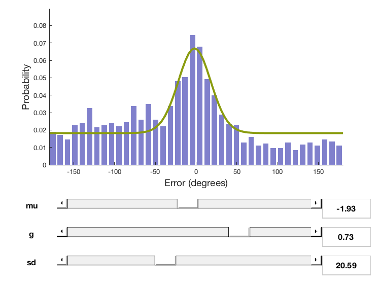

```matlab
disp('subjects collapsed; individually all subjects were able to converge')
cd '/Users/scotti.5/Dropbox/Shared Lab Folder/Experiments/Contextual_LTM/Contextual bias in LTM Exp_V3/analysis'
openfig('neigh_coll_SMM.fig');
```

```
Following are histograms of each subject's data for neighboring quadrants, fit to standard mixture model
sorry the titles didn't come out correctly, which would have given their subject number
```

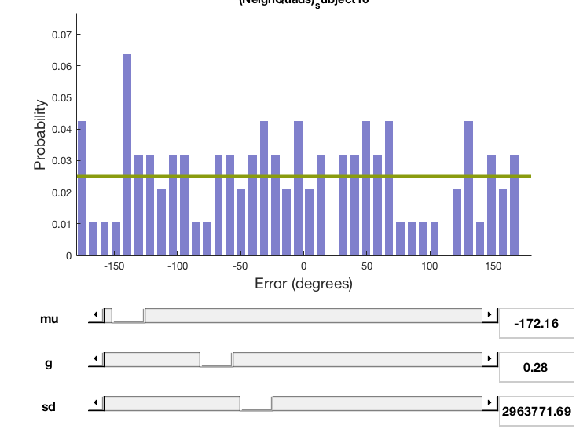

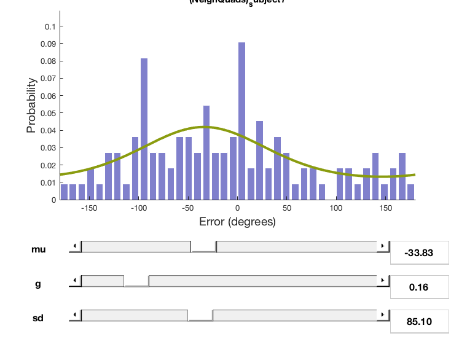

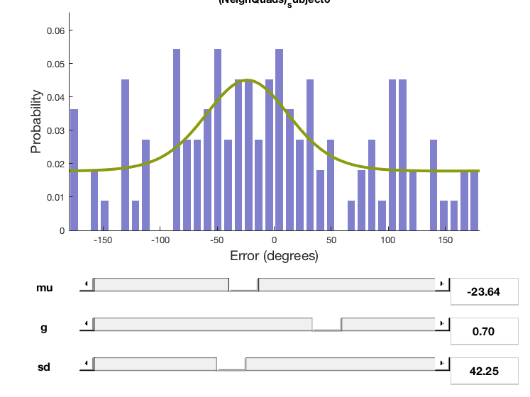

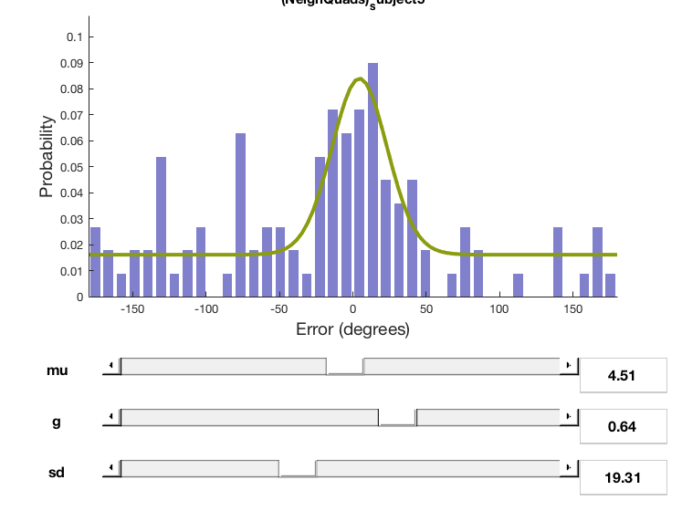

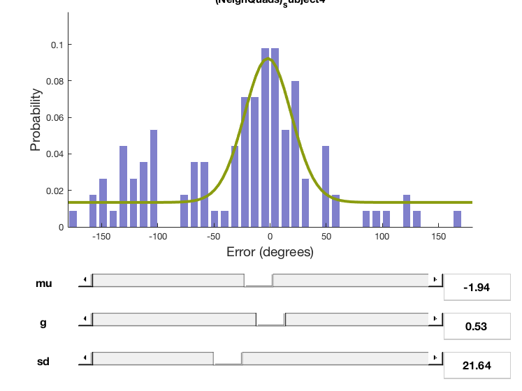

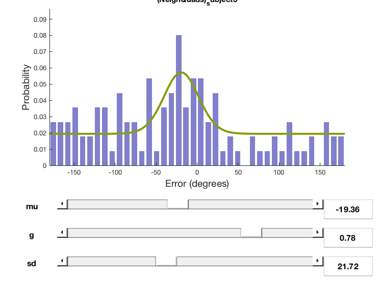

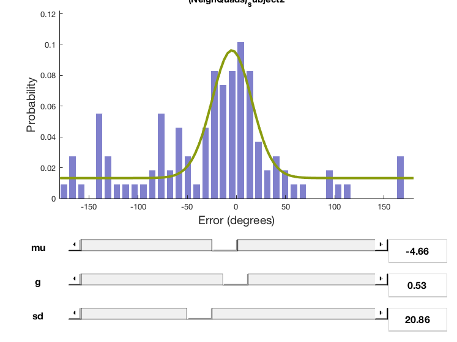

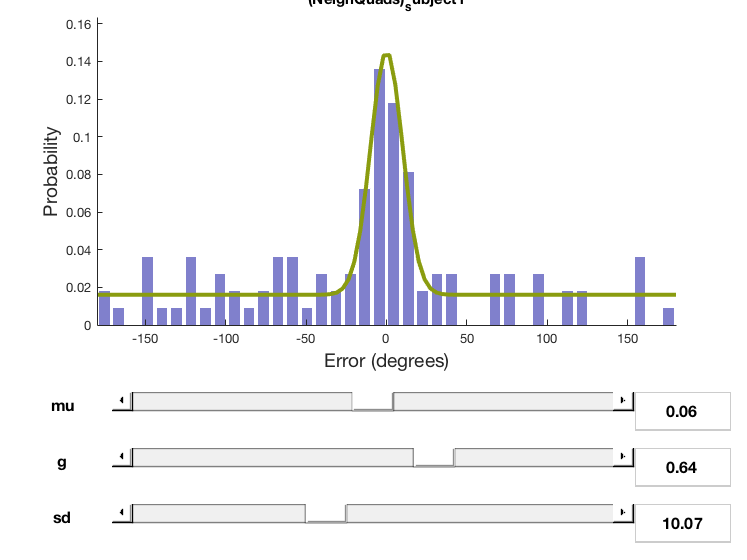

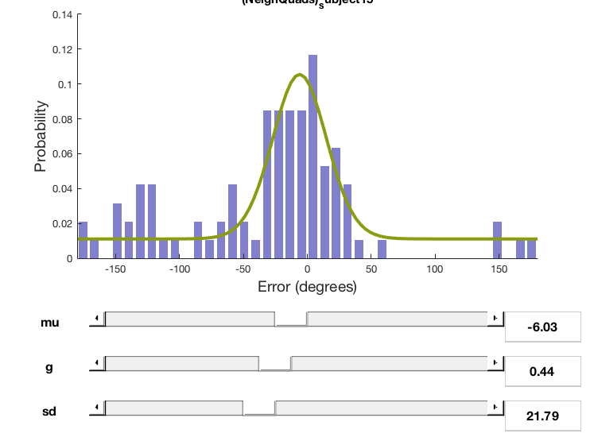

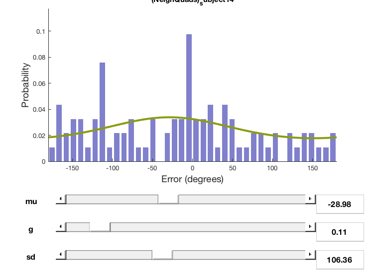

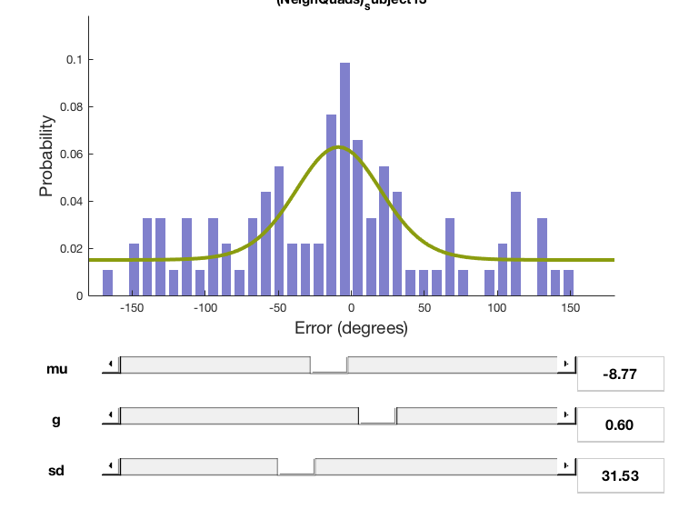

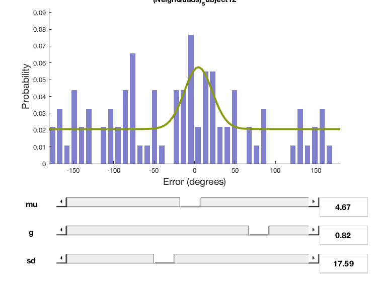

[4 more figures not shown]

```matlab
disp('Following are histograms of each subject''s data for neighboring quadrants, fit to standard mixture model');
disp('sorry the titles didn''t come out correctly, which would have given their subject number');
cd '/Users/scotti.5/Dropbox/Shared Lab Folder/Experiments/Contextual_LTM/Contextual bias in LTM Exp_V3/analysis'
openfig('subject1.fig');
openfig('subject2.fig');
openfig('subject3.fig');
openfig('subject4.fig');
openfig('subject5.fig');
openfig('subject6.fig');
openfig('subject7.fig');
openfig('subject8.fig');
openfig('subject9.fig');
openfig('subject10.fig');
openfig('subject11.fig');
openfig('subject12.fig');
openfig('subject13.fig');
openfig('subject14.fig');
openfig('subject15.fig');
openfig('subject16.fig');
```

## Comments

*While all the above individual subjects converged, some of them messed up really bad. Huge standard deviations or a near zero guess distribution. I can of course limit the standard deviation max, but this is a concern. We need to consider what criteria to use to eliminate subjects, as some show pretty much no target distribution which of course the model will have trouble with.*

### Neighboring Quadrants (collapsed), Swap Model (individual distractors, flexible stdev for guessing distr.)

```
subjects collapsed; individually all subjects were able to converge
```

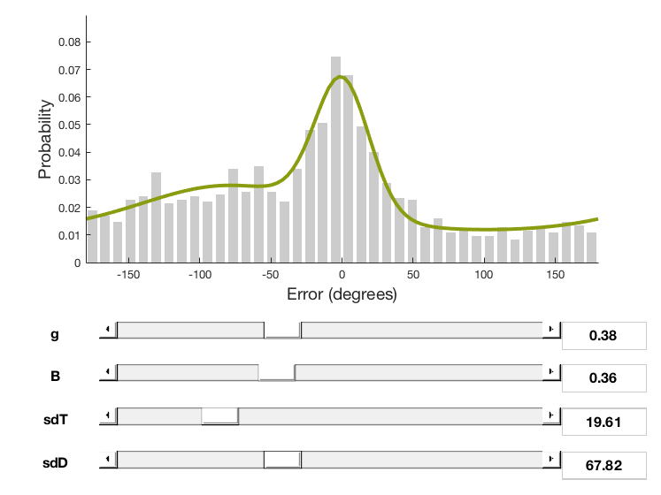

```matlab
disp('subjects collapsed; individually all subjects were able to converge')
cd '/Users/scotti.5/Dropbox/Shared Lab Folder/Experiments/Contextual_LTM/Contextual bias in LTM Exp_V3/analysis'
openfig('neigh_coll_SwapModel_freeSD.fig');
```

```
Following are histograms of each subject's data for neighboring quadrants, fit to above swap model
```

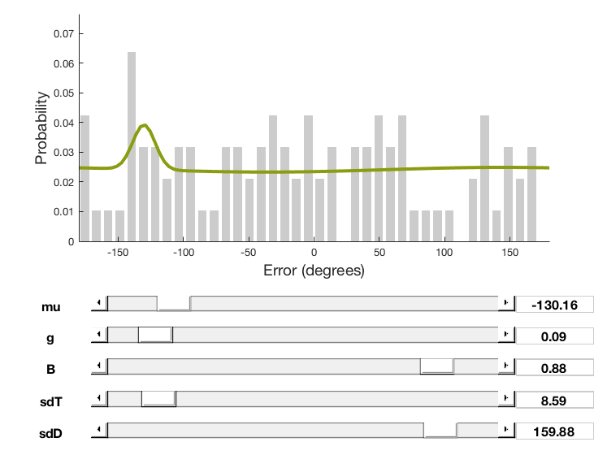

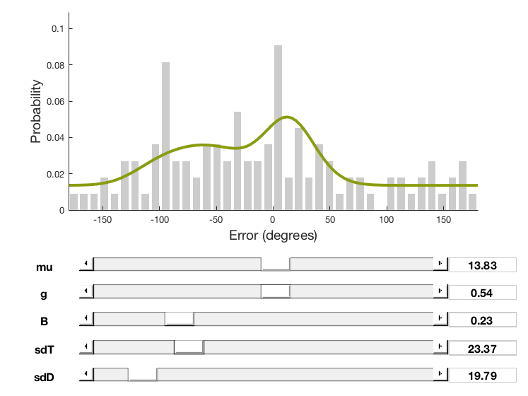

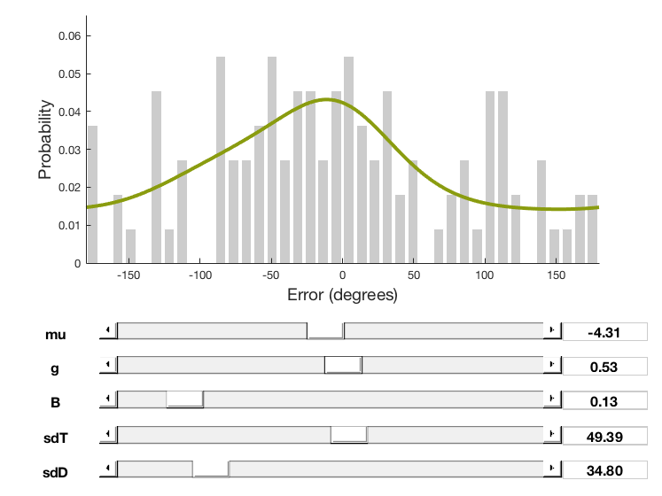

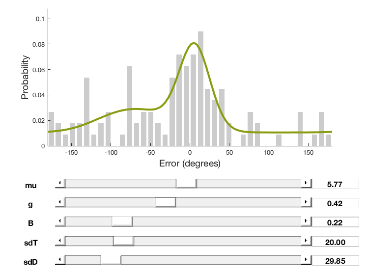

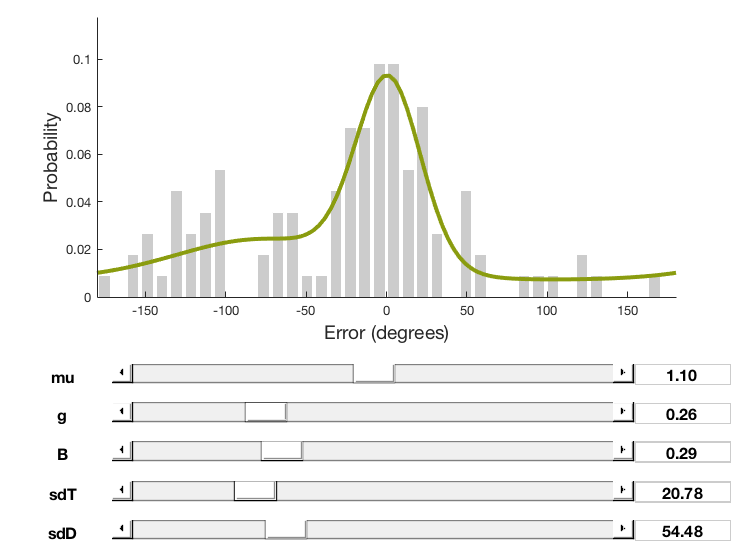

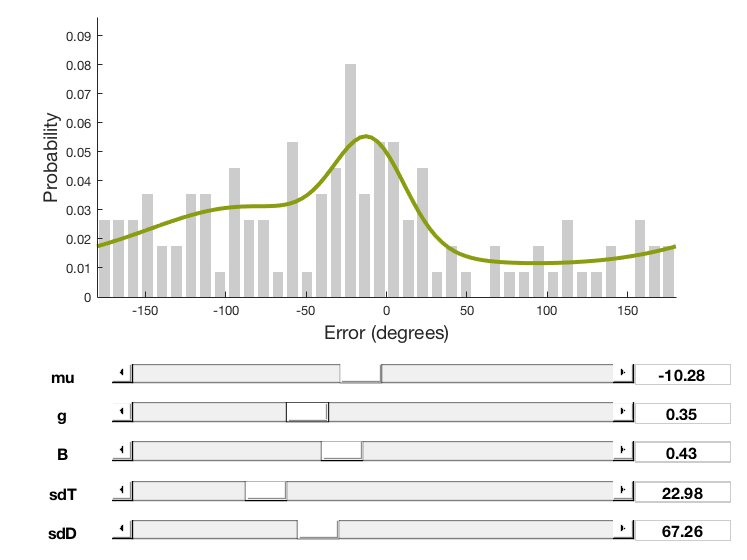

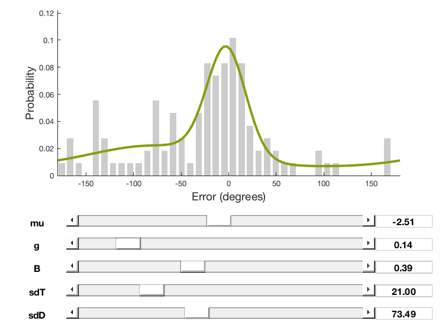

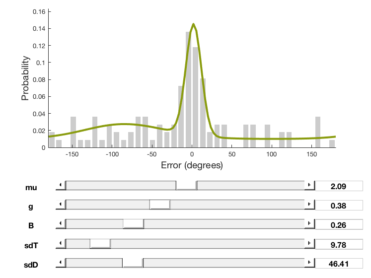

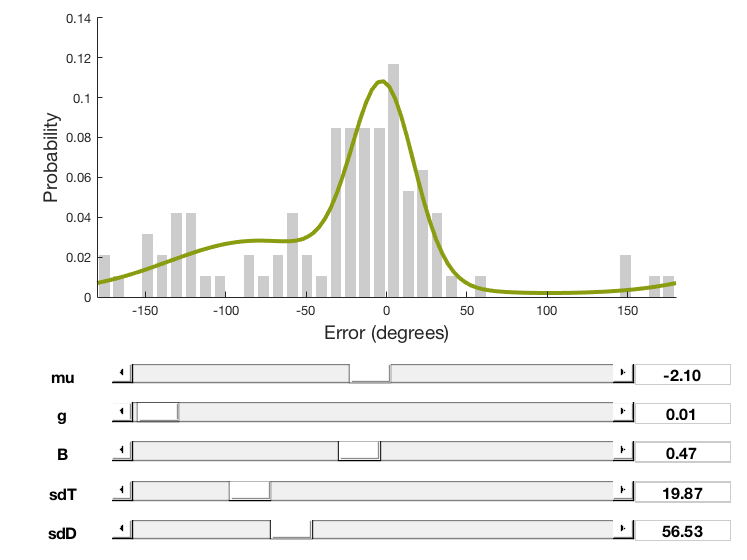

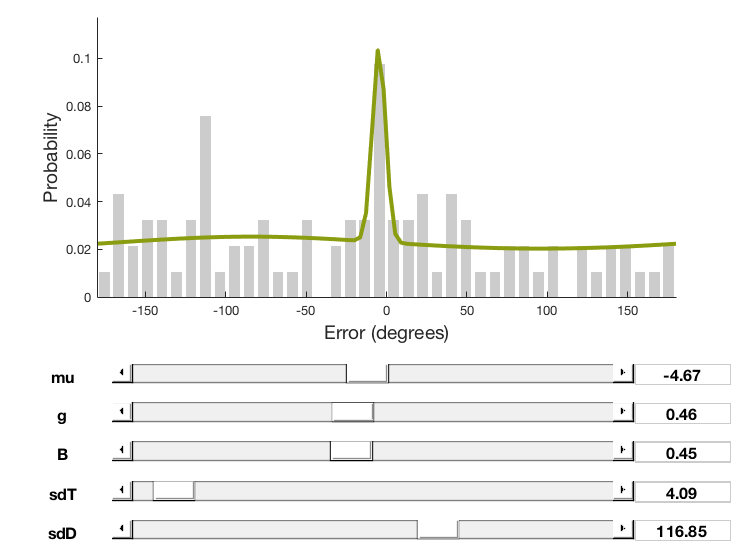

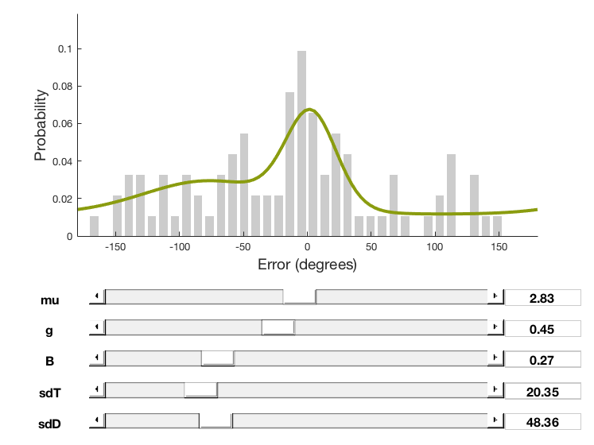

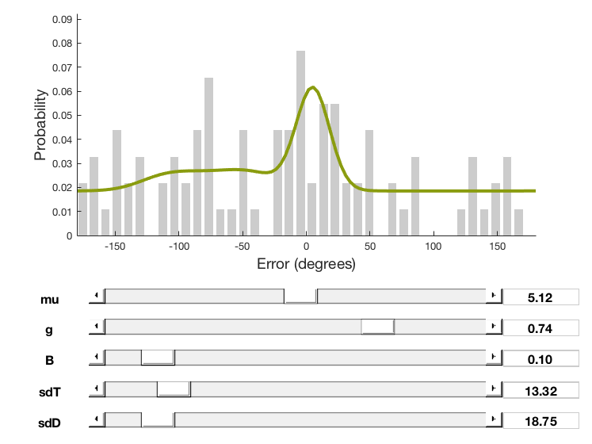

[4 more figures not shown]

```matlab
disp('Following are histograms of each subject''s data for neighboring quadrants, fit to above swap model');
cd '/Users/scotti.5/Dropbox/Shared Lab Folder/Experiments/Contextual_LTM/Contextual bias in LTM Exp_V3/analysis'
openfig('swap_subject1.fig');
openfig('swap_subject2.fig');
openfig('swap_subject3.fig');
openfig('swap_subject4.fig');
openfig('swap_subject5.fig');
openfig('swap_subject6.fig');
openfig('swap_subject7.fig');
openfig('swap_subject8.fig');
openfig('swap_subject9.fig');
openfig('swap_subject10.fig');
openfig('swap_subject11.fig');
openfig('swap_subject12.fig');
openfig('swap_subject13.fig');
openfig('swap_subject14.fig');
openfig('swap_subject15.fig');
openfig('swap_subject16.fig');
```

- Mean shift: -7.38
- Mean guessing distribution across individuals: 32.8%
- Mean biased distribution across individuals: 36.5%
- *This means target distribution was the remainder, or approximately 30.7% of responses*
- Mean stdev of target distribution across individuals: 22.53
- Mean stdev of biased distribution across individuals: 46.57

### All Quadrants, Swap Model (individual distractors, flexible stdev for guessing distr.)

```
Subjects collapsed:
```

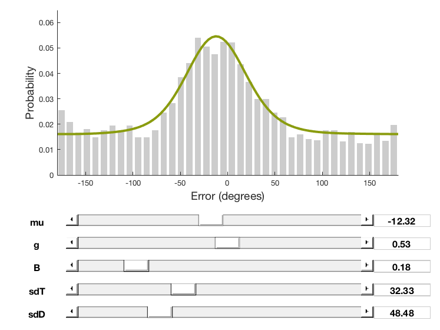

```matlab
disp('Subjects collapsed:');
cd '/Users/scotti.5/Dropbox/Shared Lab Folder/Experiments/Contextual_LTM/Contextual bias in LTM Exp_V3/analysis'
openfig('allquad_swap_collapsed.fig');
```